```python
import sys

assert sys.version_info >= (3, 7)
```

```python
from packaging import version
import tensorflow as tf

assert version.parse(tf.__version__) >= version.parse("2.8.0")
```

```python
import matplotlib.pyplot as plt

plt.rc('font', size=14)
plt.rc('axes', labelsize=14, titlesize=14)
plt.rc('legend', fontsize=14)
plt.rc('xtick', labelsize=10)
plt.rc('ytick', labelsize=10)
```

# Problem zanikających/eksplodujących gradientów

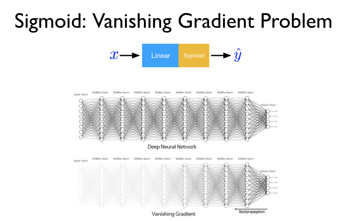

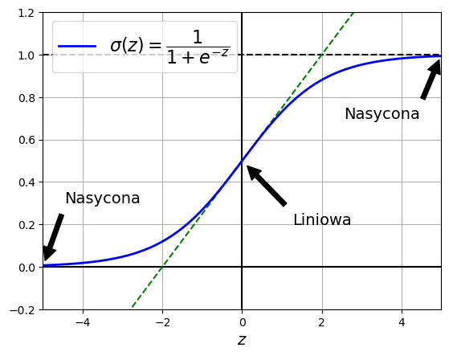

```python
import numpy as np

def sigmoid(z):
    return 1 / (1 + np.exp(-z))

z = np.linspace(-5, 5, 200)

plt.plot([-5, 5], [0, 0], 'k-')
plt.plot([-5, 5], [1, 1], 'k--')
plt.plot([0, 0], [-0.2, 1.2], 'k-')
plt.plot([-5, 5], [-3/4, 7/4], 'g--')
plt.plot(z, sigmoid(z), "b-", linewidth=2,
         label=r"$\sigma(z) = \dfrac{1}{1+e^{-z}}$")
props = dict(facecolor='black', shrink=0.1)
plt.annotate('Nasycona', xytext=(3.5, 0.7), xy=(5, 1), arrowprops=props,
             fontsize=14, ha="center")
plt.annotate('Nasycona', xytext=(-3.5, 0.3), xy=(-5, 0), arrowprops=props,
             fontsize=14, ha="center")
plt.annotate('Liniowa', xytext=(2, 0.2), xy=(0, 0.5), arrowprops=props,
             fontsize=14, ha="center")
plt.grid(True)
plt.axis([-5, 5, -0.2, 1.2])
plt.xlabel("$z$")
plt.legend(loc="upper left", fontsize=16)
plt.show()
```

Patrząc na funkcję `sigmoid`, można zauważyć, że gdy dane wejściowe stają się duże (ujemne lub dodatnie), funkcja nasyca się przy poziomie 0 lub 1, z pochodną bardzo bliską 0. Zatem, gdy rozpoczyna się propagacja wsteczna praktycznie nie ma gradientu, który mógłby się rozprzestrzenić w sieci; a ten niewielki gradient, który istnieje, ulega rozrzedzeniu w miarę postępu propagacji wstecznej w dół przez górne warstwy, więc tak naprawdę nic nie pozostaje dla niższych warstw.

## Inicjalizacja początkowych wartości wag Glorot, He i LeCun

Glorot dla funkcji `sigmoid`: losowanie wag początkowych

Inne inicjalizacje wag początkowych (dla rozkładu jednostajnego wystarczy użyć wzoru: $r = \sqrt{3\sigma^2}$:

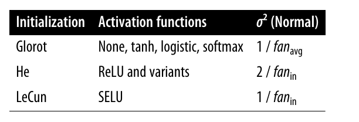

**Domyślnie Keras wykorzystuje inicjalizację wag Glorota z rozkładem jednostajnym** Możesz to zmienić:

```python
dense = tf.keras.layers.Dense(50, activation="relu", kernel_initializer="he_normal")
```

```python
he_avg_init = tf.keras.initializers.VarianceScaling(scale=2., mode="fan_avg", distribution="uniform")
dense = tf.keras.layers.Dense(50, activation="sigmoid", kernel_initializer=he_avg_init)
```

## Problem umierających neuronów

### Przeciekająca funkcja ReLU i PReLu

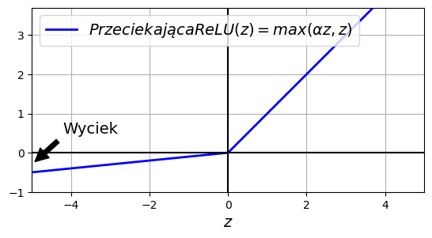

```python
def leaky_relu(z, alpha):
    return np.maximum(alpha * z, z)

z = np.linspace(-5, 5, 200)
plt.plot(z, leaky_relu(z, 0.1), "b-", linewidth=2, label=r"$Przeciekająca ReLU(z) = max(\alpha z, z)$")
plt.plot([-5, 5], [0, 0], 'k-')
plt.plot([0, 0], [-1, 3.7], 'k-')
plt.grid(True)
props = dict(facecolor='black', shrink=0.1)
plt.annotate('Wyciek', xytext=(-3.5, 0.5), xy=(-5, -0.3), arrowprops=props,
             fontsize=14, ha="center")
plt.xlabel("$z$")
plt.axis([-5, 5, -1, 3.7])
plt.gca().set_aspect("equal")
plt.legend()

plt.show()
```

```python
leaky_relu = tf.keras.layers.LeakyReLU(alpha=0.2)  # domyślnie alpha=0.3
dense = tf.keras.layers.Dense(50, activation=leaky_relu, kernel_initializer="he_normal")
```

Jeśli wolisz, możesz również użyć LeakyReLU jako osobnej warstwy w swoim modelu; nie ma to znaczenia dla treningu i prognoz:

```python
model = tf.keras.models.Sequential([
    # [...]  # więcej warstw
    tf.keras.layers.Dense(50, kernel_initializer="he_normal"),  # bez aktywacji
    tf.keras.layers.LeakyReLU(alpha=0.2),  # aktywacja jako osobna warstwa
    # [...]  # więcej warstw
])
```

### Funkcja aktywacji ELU

Wszystkie ReLU, przeciekające ReLU i PReLU mają tę wadę, że nie są funkcjami gładkimi: ich pochodne zmieniają się gwałtownie (przy z = 0). Ten rodzaj nieciągłości może spowodować, że opadanie gradientu będzie odbijać się od optimum i spowolnić zbieżność. Zatem teraz przyjrzymy się pewnym płynnym wariantom funkcji aktywacji ReLU, zaczynając od ELU i SELU.

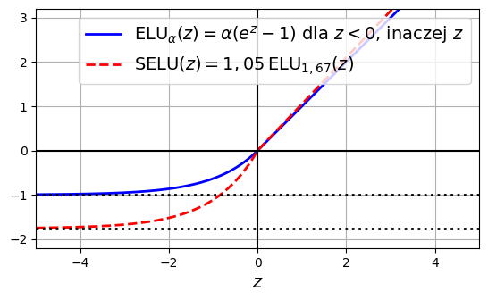

```python
from scipy.special import erfc

# zmienne alpha i scale służą do samonormalizacji ze średnią 0 i odchyleniem standardowym 1
# (zob. równanie 14. we wspomnianej publikacji):
alpha_0_1 = -np.sqrt(2 / np.pi) / (erfc(1 / np.sqrt(2)) * np.exp(1 / 2) - 1)
scale_0_1 = (
    (1 - erfc(1 / np.sqrt(2)) * np.sqrt(np.e))
    * np.sqrt(2 * np.pi)
    * (
        2 * erfc(np.sqrt(2)) * np.e ** 2
        + np.pi * erfc(1 / np.sqrt(2)) ** 2 * np.e
        - 2 * (2 + np.pi) * erfc(1 / np.sqrt(2)) * np.sqrt(np.e)
        + np.pi
        + 2
    ) ** (-1 / 2)
)

def elu(z, alpha=1):
    return np.where(z < 0, alpha * (np.exp(z) - 1), z)

def selu(z, scale=scale_0_1, alpha=alpha_0_1):
    return scale * elu(z, alpha)

z = np.linspace(-5, 5, 200)
plt.plot(z, elu(z), "b-", linewidth=2, label=r"ELU$_\alpha(z) = \alpha (e^z - 1)$ dla $z < 0$, inaczej $z$")
plt.plot(z, selu(z), "r--", linewidth=2, label=r"SELU$(z) = 1,05 \, $ELU$_{1,67}(z)$")
plt.plot([-5, 5], [0, 0], 'k-')
plt.plot([-5, 5], [-1, -1], 'k:', linewidth=2)
plt.plot([-5, 5], [-1.758, -1.758], 'k:', linewidth=2)
plt.plot([0, 0], [-2.2, 3.2], 'k-')
plt.grid(True)
plt.axis([-5, 5, -2.2, 3.2])
plt.xlabel("$z$")
plt.gca().set_aspect("equal")
plt.legend()
plt.show()
```

Implementacja funkcji aktywacji ELU w module TensorFlow jest banalna, wystarczy określić funkcję aktywacji podczas budowania każdej warstwy i wprowadzić inicjalizację He:

```python
dense = tf.keras.layers.Dense(50, activation="elu", kernel_initializer="he_normal")
```

### Funkcja aktywacji SELU

Skalowana funkcja aktywacji ELU (SELU): jak sama nazwa wskazuje, jest to skalowany wariant funkcji aktywacji ELU (około 1,05 razy ELU, przy użyciu α ≈ 1,67). Pomysłodawca pokazał, że jeśli zbudujesz sieć neuronową złożoną wyłącznie ze stosu gęstych warstw i jeśli wszystkie warstwy ukryte skorzystają z funkcji aktywacji SELU, to sieć będzie się samonormalizować: wyjście każdej warstwy będzie miało tendencję do tego, aby podczas treningu zachować średnią 0 i odchylenie standardowe 1, co rozwiązuje problem zanikających/eksplodujących gradientów. W rezultacie funkcja aktywacji SELU może przewyższać inne funkcje aktywacji dla gęstych NN, zwłaszcza głębokich.

Istnieje jednak kilka warunków, w których może nastąpić samonormalizacja (zobacz artykuł matematycznego uzasadnienia):

- Cechy wejściowe muszą być standaryzowane: średnia 0 i odchylenie standardowe 1.
- Wagi każdej warstwy ukrytej muszą zostać zainicjowane przy użyciu normalnej inicjalizacji LeCun. W Keras oznacza to ustawienie `kernel_initializer="lecun_normal"`.
- Właściwość samonormalizacji jest gwarantowana tylko w przypadku zwykłych MLP. Jeśli spróbujesz użyć SELU w innych architekturach, takich jak sieci rekurencyjne lub sieci z pomijanymi połączeniami (tj. połączeniami pomijającymi warstwy, jak w sieciach szerokich i głębokich), prawdopodobnie nie będzie to lepsze od ELU.
- Nie można używać technik regularyzacji, takich jak regularyzacja `l1` lub `l2`, norma maksymalna, norma wsadowa lub klasyczne porzucanie (będą omówione w dalszej części).

Domyślnie hiperparametry funkcji SELU (`scale` i `alpha`) są dostrojone w taki sposób, że średni sygnał wychodzący z każdego neuronu pozostaje zbliżony do 0, a odchylenie standardowe jest bliskie 1 (przy założeniu, że sygnały wejściowe są również w ten sposób standaryzowane oraz przestrzegane są inne opisane poniżej ograniczenia). Dzięki tej funkcji aktywacji nawet tysiącwarstwowa głęboka sieć neuronowa zachowuje we wszystkich warstwach średnią zbliżoną do 0 i odchylenie standardowe zbliżone do 1, co pozwala uniknąć problemu eksplodujących/zanikających gradientów:

Korzystanie z funkcji SELU jest łatwe:

```python
dense = tf.keras.layers.Dense(50, activation="selu", kernel_initializer="lecun_normal")
```

**Zawartość dodatkowa – przykład samoregularyzującej się sieci za pomocą funkcji aktywacji SELU**

Stwórzmy sieć neuronową dla zestawu danych Fashion MNIST, zawierającą 100 warstw ukrytych i funkcję aktywacji SELU:

```python
tf.random.set_seed(42)
model = tf.keras.Sequential()
model.add(tf.keras.layers.Flatten(input_shape=[28, 28]))
for layer in range(100):
    model.add(tf.keras.layers.Dense(100, activation="selu",
                                    kernel_initializer="lecun_normal"))
model.add(tf.keras.layers.Dense(10, activation="softmax"))
```

```python
#model.summary()
```

```python
model.compile(loss="sparse_categorical_crossentropy",
              optimizer=tf.keras.optimizers.SGD(learning_rate=0.001),
              metrics=["accuracy"])
```

Wytrenujmy ją teraz. Nie zapomnij przeskalować danych wejściowych:

```python
fashion_mnist = tf.keras.datasets.fashion_mnist.load_data()
(X_train_full, y_train_full), (X_test, y_test) = fashion_mnist
X_train, y_train = X_train_full[:-5000], y_train_full[:-5000]
X_valid, y_valid = X_train_full[-5000:], y_train_full[-5000:]
X_train, X_valid, X_test = X_train / 255, X_valid / 255, X_test / 255
```

```python
class_names = ["Koszulka", "Spodnie", "Sweter", "Sukienka", "Płaszcz",
               "Sandał", "Koszula", "Tenisówka", "Torebka", "Trzewik"]
```

```python
pixel_means = X_train.mean(axis=0, keepdims=True)
pixel_stds = X_train.std(axis=0, keepdims=True)
X_train_scaled = (X_train - pixel_means) / pixel_stds
X_valid_scaled = (X_valid - pixel_means) / pixel_stds
X_test_scaled = (X_test - pixel_means) / pixel_stds
```

```python
history = model.fit(X_train_scaled, y_train, epochs=5,
                    validation_data=(X_valid_scaled, y_valid))
```

Sprawdźmy teraz, co się stanie, jeśli zastąpimy funkcję SELU funkcją ReLU:

```python
tf.random.set_seed(42)
```

```python
model = tf.keras.Sequential()
model.add(tf.keras.layers.Flatten(input_shape=[28, 28]))
for layer in range(100):
    model.add(tf.keras.layers.Dense(100, activation="relu",
                                    kernel_initializer="he_normal"))
model.add(tf.keras.layers.Dense(10, activation="softmax"))
```

```python
model.compile(loss="sparse_categorical_crossentropy",
              optimizer=tf.keras.optimizers.SGD(learning_rate=0.001),
              metrics=["accuracy"])
```

```python
history = model.fit(X_train_scaled, y_train, epochs=5,
                    validation_data=(X_valid_scaled, y_valid))
```

### Funkcje GELU, Swish i Mish

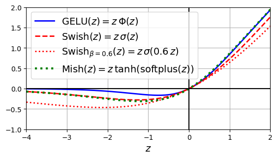

```python
def swish(z, beta=1):
    return z * sigmoid(beta * z)

def approx_gelu(z):
    return swish(z, beta=1.702)

def softplus(z):
    return np.log(1 + np.exp(z))

def mish(z):
    return z * np.tanh(softplus(z))

z = np.linspace(-4, 2, 200)

beta = 0.6
plt.plot(z, approx_gelu(z), "b-", linewidth=2,
         label=r"GELU$(z) = z\,\Phi(z)$")
plt.plot(z, swish(z), "r--", linewidth=2,
         label=r"Swish$(z) = z\,\sigma(z)$")
plt.plot(z, swish(z, beta), "r:", linewidth=2,
         label=fr"Swish$_{{\beta={beta}}}(z)=z\,\sigma({beta}\,z)$")
plt.plot(z, mish(z), "g:", linewidth=3,
         label=fr"Mish$(z) = z\,\tanh($softplus$(z))$")
plt.plot([-4, 2], [0, 0], 'k-')
plt.plot([0, 0], [-2.2, 3.2], 'k-')
plt.grid(True)
plt.axis([-4, 2, -1, 2])
plt.gca().set_aspect("equal")
plt.xlabel("$z$")
plt.legend(loc="upper left")
plt.show()
```

**Której funkcji aktywacji używać?** ReLU pozostaje dobrym rozwiązaniem domyślnym w przypadku prostych zadań: często jest tak samo dobre, jak bardziej wyrafinowane funkcje aktywacyjne, a ponadto jest bardzo szybkie w obliczeniach, a wiele bibliotek i akceleratorów sprzętowych zapewnia optymalizacje specyficzne dla ReLU. Jednak Swish jest prawdopodobnie lepszym rozwiązaniem domyślnym w przypadku bardziej złożonych zadań, a w przypadku najbardziej złożonych zadań można nawet wypróbować sparametryzowany Swish z możliwym do nauczenia się parametrem β. Mish może dać nieco lepsze wyniki, ale wymaga nieco więcej obliczeń. Jeśli bardzo zależy Ci na opóźnieniu w czasie wykonywania, możesz preferować nieszczelne ReLU lub sparametryzowane nieszczelne ReLU do bardziej złożonych zadań. W przypadku głębokich MLP wypróbuj SELU, ale pamiętaj o przestrzeganiu ograniczeń wymienionych wcześniej. Jeśli masz wolny czas i moc obliczeniową, możesz użyć sprawdzania krzyżowego, aby ocenić również inne funkcje aktywacyjne.

# Normalizacja wsadowa

```python
# dodatkowy kod - zeruje liczniki nazw i wyznacza ziarno losowości
tf.keras.backend.clear_session()
tf.random.set_seed(42)
```

```python
model = tf.keras.Sequential([
    tf.keras.layers.Flatten(input_shape=[28, 28]),
    tf.keras.layers.BatchNormalization(),
    tf.keras.layers.Dense(300, activation="relu",
                          kernel_initializer="he_normal"),
    tf.keras.layers.BatchNormalization(),
    tf.keras.layers.Dense(100, activation="relu",
                          kernel_initializer="he_normal"),
    tf.keras.layers.BatchNormalization(),
    tf.keras.layers.Dense(10, activation="softmax")
])
```

```python
model.summary()
```

```
Model: "sequential"
_________________________________________________________________
 Layer (type)                Output Shape              Param #
=================================================================
 flatten (Flatten)           (None, 784)               0

 batch_normalization (BatchN  (None, 784)              3136
 ormalization)

 dense (Dense)               (None, 300)               235500

 batch_normalization_1 (Batc  (None, 300)              1200
 hNormalization)

 dense_1 (Dense)             (None, 100)               30100

 batch_normalization_2 (Batc  (None, 100)              400
 hNormalization)

 dense_2 (Dense)             (None, 10)                1010

=================================================================
Total params: 271,346
Trainable params: 268,978
Non-trainable params: 2,368
_________________________________________________________________
```

```python
[(var.name, var.trainable) for var in model.layers[1].variables]
```

```
[('batch_normalization/gamma:0', True),
 ('batch_normalization/beta:0', True),
 ('batch_normalization/moving_mean:0', False),
 ('batch_normalization/moving_variance:0', False)]
```

```python
# dodatkowy kod – pokazuje tylko, że model działa! 😊
model.compile(loss="sparse_categorical_crossentropy", optimizer="sgd",
              metrics="accuracy")
model.fit(X_train, y_train, epochs=2, validation_data=(X_valid, y_valid))
```

```
<keras.callbacks.History at 0x7f994b6354b0>
```

Czasami wprowadzanie normalizacji wsadowej przed funkcją aktywacji sprawdza się lepiej (kwestia ta ciągle jest tematem dyskusji). Ponadto warstwa poprzedzająca warstwę `BatchNormalization` nie wymaga członów obciążenia, ponieważ zawiera je warstwa `BatchNormalization`, zatem aby uniknąć marnotrawienia parametrów, możesz wyznaczyć `use_bias=False` podczas tworzenia tych warstw:

```python
# dodatkowy kod - zeruje liczniki nazw i wyznacza ziarno losowości
tf.keras.backend.clear_session()
tf.random.set_seed(42)
```

```python
model = tf.keras.Sequential([
    tf.keras.layers.Flatten(input_shape=[28, 28]),
    tf.keras.layers.Dense(300, kernel_initializer="he_normal", use_bias=False),
    tf.keras.layers.BatchNormalization(),
    tf.keras.layers.Activation("relu"),
    tf.keras.layers.Dense(100, kernel_initializer="he_normal", use_bias=False),
    tf.keras.layers.BatchNormalization(),
    tf.keras.layers.Activation("relu"),
    tf.keras.layers.Dense(10, activation="softmax")
])
```

```python
# dodatkowy kod – pokazuje tylko, że model działa! 😊
model.compile(loss="sparse_categorical_crossentropy", optimizer="sgd",
              metrics="accuracy")
model.fit(X_train, y_train, epochs=2, validation_data=(X_valid, y_valid))
```

```
<keras.callbacks.History at 0x7f9947de80a0>
```

# Szybsze optymalizatory

```python
# dodatkowy kod – mała funkcja testująca optymaliztor na zestawie danych Fashion MNIST

def build_model(seed=42):
    tf.random.set_seed(seed)
    return tf.keras.Sequential([
        tf.keras.layers.Flatten(input_shape=[28, 28]),
        tf.keras.layers.Dense(100, activation="relu",
                              kernel_initializer="he_normal"),
        tf.keras.layers.Dense(100, activation="relu",
                              kernel_initializer="he_normal"),
        tf.keras.layers.Dense(100, activation="relu",
                              kernel_initializer="he_normal"),
        tf.keras.layers.Dense(10, activation="softmax")
    ])

def build_and_train_model(optimizer):
    model = build_model()
    model.compile(loss="sparse_categorical_crossentropy", optimizer=optimizer,
                  metrics=["accuracy"])
    return model.fit(X_train, y_train, epochs=10,
                     validation_data=(X_valid, y_valid))
```

```python
optimizer = tf.keras.optimizers.SGD(learning_rate=0.001, momentum=0.9)
```

```python
history_sgd = build_and_train_model(optimizer)  # dodatkowy kod
```

## Optymalizacja momentum

```python
optimizer = tf.keras.optimizers.SGD(learning_rate=0.001, momentum=0.9)
```

```python
history_momentum = build_and_train_model(optimizer)  # dodatkowy kod
```

## Algorytm przyspieszonego gradientu Nesterova

```python
optimizer = tf.keras.optimizers.SGD(learning_rate=0.001, momentum=0.9,
                                    nesterov=True)
```

```python
history_nesterov = build_and_train_model(optimizer)  # dodatkowy kod
```

## AdaGrad

```python
optimizer = tf.keras.optimizers.Adagrad(learning_rate=0.001)
```

```python
history_adagrad = build_and_train_model(optimizer)  # dodatkowy kod
```

## RMSProp

```python
optimizer = tf.keras.optimizers.RMSprop(learning_rate=0.001, rho=0.9)
```

```python
history_rmsprop = build_and_train_model(optimizer)  # dodatkowy kod
```

## Optymalizacja Adam

```python
optimizer = tf.keras.optimizers.Adam(learning_rate=0.001, beta_1=0.9,
                                     beta_2=0.999)
```

```python
history_adam = build_and_train_model(optimizer)  # dodatkowy kod
```

**Optymalizacja Adamax**

```python
optimizer = tf.keras.optimizers.Adamax(learning_rate=0.001, beta_1=0.9,
                                       beta_2=0.999)
```

```python
history_adamax = build_and_train_model(optimizer)  # dodatkowy kod
```

**Optymalizacja Nadam**

```python
optimizer = tf.keras.optimizers.Nadam(learning_rate=0.001, beta_1=0.9,
                                      beta_2=0.999)
```

```python
history_nadam = build_and_train_model(optimizer)  # dodatkowy kod
```

**Optymalizacja AdamW**

W środowiskach Colab lub Kaggle musimy zainstalować bibliotekę TensorFlow-Addons:

```python
import tensorflow_addons as tfa

optimizer = tfa.optimizers.AdamW(weight_decay=1e-5, learning_rate=0.001,
                                 beta_1=0.9, beta_2=0.999)
```

```python
history_adamw = build_and_train_model(optimizer)  # dodatkowy kod
```

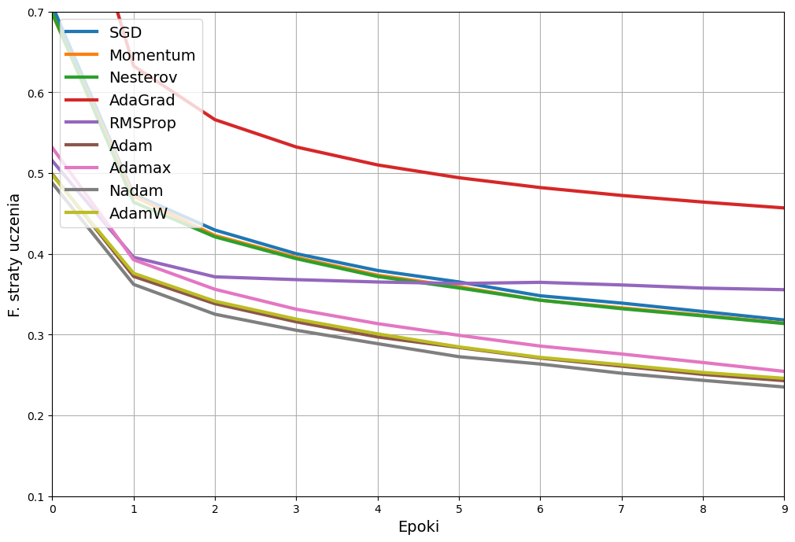

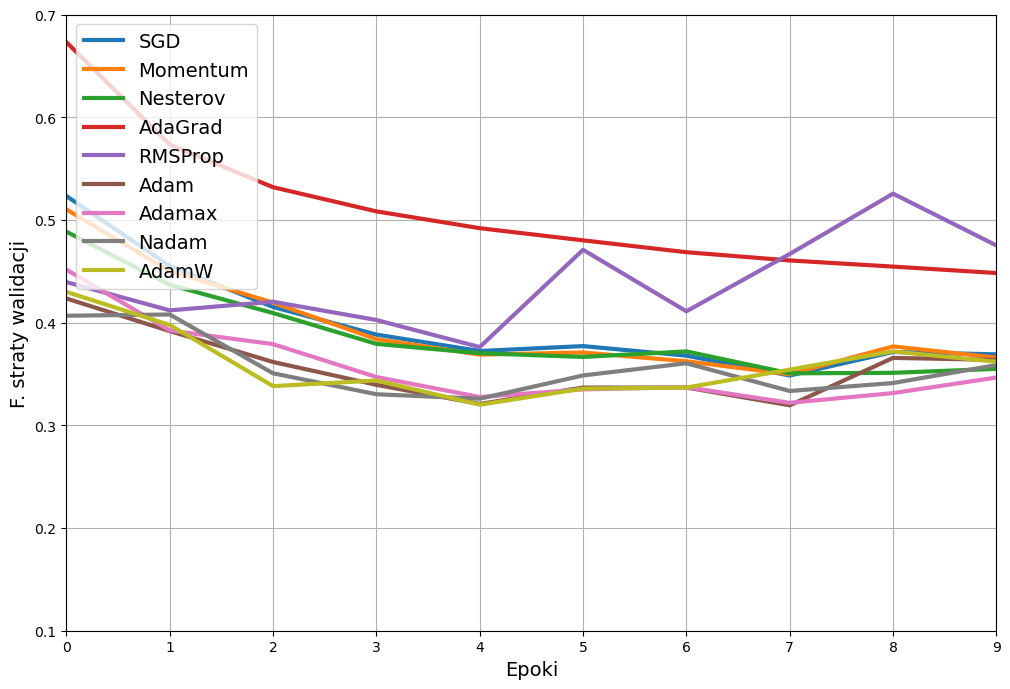

```python
# dodatkowy kod – wizualizuje krzywe uczenia wszystkich optymalizatorów

for loss in ("loss", "val_loss"):
    plt.figure(figsize=(12, 8))
    opt_names = "SGD Momentum Nesterov AdaGrad RMSProp Adam Adamax Nadam AdamW"
    for history, opt_name in zip((history_sgd, history_momentum, history_nesterov,
                                  history_adagrad, history_rmsprop, history_adam,
                                  history_adamax, history_nadam, history_adamw),
                                 opt_names.split()):
        plt.plot(history.history[loss], label=f"{opt_name}", linewidth=3)

    plt.grid()
    plt.xlabel("Epoki")
    plt.ylabel({"loss": "F. straty uczenia", "val_loss": "F. straty walidacji"}[loss])
    plt.legend(loc="upper left")
    plt.axis([0, 9, 0.1, 0.7])
    plt.show()
```

**Którego optymalizatora używać?**

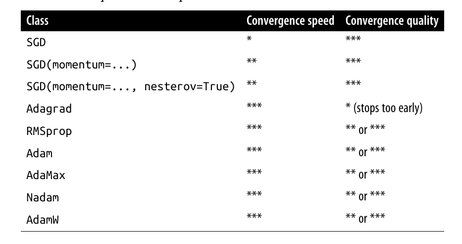

## Harmonogramowanie współczynnika uczenia

Jeśli zaczniesz od dużego współczynnika uczenia się, a następnie zmniejszysz je, gdy trening przestanie robić szybkie postępy, możesz osiągnąć dobre rozwiązanie szybciej niż przy optymalnej stałej szybkości uczenia się.

### Harmonogramowanie potęgowe

`lr = lr0 / (1 + kroki / s)**c`

- Keras wykorzystuje `c=1` i `s = 1 / rozkład`

```python
optimizer = tf.keras.optimizers.SGD(learning_rate=0.01, decay=1e-4)
```

```python
history_power_scheduling = build_and_train_model(optimizer)  # dodatkowy kod
```

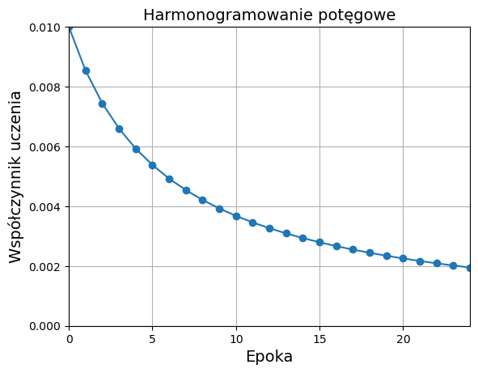

```python
# dodatkowy kod – komórka ta tworzy wykres harmonogramowania potęgowego

import math

learning_rate = 0.01
decay = 1e-4
batch_size = 32
n_steps_per_epoch = math.ceil(len(X_train) / batch_size)
n_epochs = 25

epochs = np.arange(n_epochs)
lrs = learning_rate / (1 + decay * epochs * n_steps_per_epoch)

plt.plot(epochs, lrs,  "o-")
plt.axis([0, n_epochs - 1, 0, 0.01])
plt.xlabel("Epoka")
plt.ylabel("Współczynnik uczenia")
plt.title("Harmonogramowanie potęgowe", fontsize=14)
plt.grid(True)
plt.show()
```

### Harmonogramowanie wykładnicze

`lr = lr0 * 0.1 ** (epoch / s)`

```python
def exponential_decay_fn(epoch):
    return 0.01 * 0.1 ** (epoch / 20)
```

```python
def exponential_decay(lr0, s):
    def exponential_decay_fn(epoch):
        return lr0 * 0.1 ** (epoch / s)
    return exponential_decay_fn

exponential_decay_fn = exponential_decay(lr0=0.01, s=20)
```

```python
# dodatkowy kod – buduje i kompiluje model dla zestawu Fashion MNIST

tf.random.set_seed(42)
model = build_model()
optimizer = tf.keras.optimizers.SGD(learning_rate=0.001)
model.compile(loss="sparse_categorical_crossentropy", optimizer=optimizer,
              metrics=["accuracy"])
```

```python
lr_scheduler = tf.keras.callbacks.LearningRateScheduler(exponential_decay_fn)
history = model.fit(X_train, y_train, epochs=n_epochs,
                    validation_data=(X_valid, y_valid),
                    callbacks=[lr_scheduler])
```

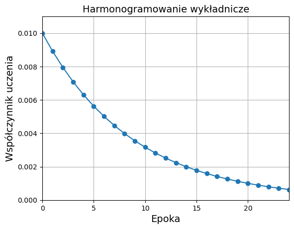

```python
# dodatkowy kod – komórka ta generuje wykres harmonogramowania wykładniczego

plt.plot(history.epoch, history.history["lr"], "o-")
plt.axis([0, n_epochs - 1, 0, 0.011])
plt.xlabel("Epoka")
plt.ylabel("Współczynnik uczenia")
plt.title("Harmonogramowanie wykładnicze", fontsize=14)
plt.grid(True)
plt.show()
```

Funkcja harmonogramowania może przyjmować bieżący współczynnik uczenia jako drugi argument:

```python
def exponential_decay_fn(epoch, lr):
    return lr * 0.1 ** (1 / 20)
```

**Materiał nadprogramowy**: jeżeli chcesz aktualizować współczynnik uczenia w każdej iteracji, a nie epoce, musisz napisać własną klasę wywołania zwrotnego:

```python
K = tf.keras.backend

class ExponentialDecay(tf.keras.callbacks.Callback):
    def __init__(self, n_steps=40_000):
        super().__init__()
        self.n_steps = n_steps

    def on_batch_begin(self, batch, logs=None):
        # Uwaga: argument `batch` jest zerowany w każdej epoce
        lr = K.get_value(self.model.optimizer.learning_rate)
        new_learning_rate = lr * 0.1 ** (1 / self.n_steps)
        K.set_value(self.model.optimizer.learning_rate, new_learning_rate)

    def on_epoch_end(self, epoch, logs=None):
        logs = logs or {}
        logs['lr'] = K.get_value(self.model.optimizer.learning_rate)
```

```python
lr0 = 0.01
model = build_model()
optimizer = tf.keras.optimizers.SGD(learning_rate=lr0)
model.compile(loss="sparse_categorical_crossentropy", optimizer=optimizer,
              metrics=["accuracy"])
```

```python
n_epochs = 25
batch_size = 32
n_steps = n_epochs * math.ceil(len(X_train) / batch_size)
exp_decay = ExponentialDecay(n_steps)
history = model.fit(X_train, y_train, epochs=n_epochs,
                    validation_data=(X_valid, y_valid),
                    callbacks=[exp_decay])
```

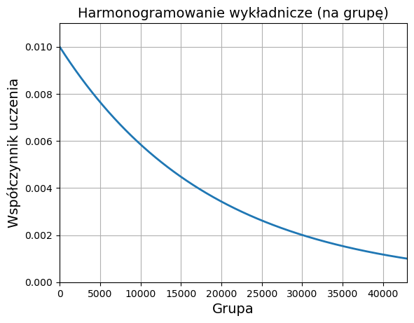

```python
n_steps = n_epochs * math.ceil(len(X_train) / batch_size)
steps = np.arange(n_steps)
decay_rate = 0.1
lrs = lr0 * decay_rate ** (steps / n_steps)

plt.plot(steps, lrs, "-", linewidth=2)
plt.axis([0, n_steps - 1, 0, lr0 * 1.1])
plt.xlabel("Grupa")
plt.ylabel("Współczynnik uczenia")
plt.title("Harmonogramowanie wykładnicze (na grupę)", fontsize=14)
plt.grid(True)
plt.show()
```

### Harmonogramowanie stałoprzedziałowe

```python
def piecewise_constant_fn(epoch):
    if epoch < 5:
        return 0.01
    elif epoch < 15:
        return 0.005
    else:
        return 0.001
```

```python
# dodatkowy kod – komórka ta ukazuje bardziej ogólny sposób definiowania
#              harmonogramowania stałoprzedziałowego.

def piecewise_constant(boundaries, values):
    boundaries = np.array([0] + boundaries)
    values = np.array(values)
    def piecewise_constant_fn(epoch):
        return values[(boundaries > epoch).argmax() - 1]
    return piecewise_constant_fn

piecewise_constant_fn = piecewise_constant([5, 15], [0.01, 0.005, 0.001])
```

```python
# dodatkowy kod – wykorzystuje tf.keras.callbacks.LearningRateScheduler tak jak wcześniej

n_epochs = 25

lr_scheduler = tf.keras.callbacks.LearningRateScheduler(piecewise_constant_fn)

model = build_model()
optimizer = tf.keras.optimizers.Nadam(learning_rate=lr0)
model.compile(loss="sparse_categorical_crossentropy", optimizer=optimizer,
              metrics=["accuracy"])
history = model.fit(X_train, y_train, epochs=n_epochs,
                    validation_data=(X_valid, y_valid),
                    callbacks=[lr_scheduler])
```

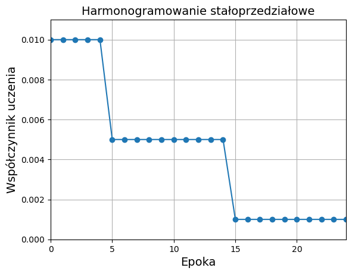

```python
# dodatkowy kod – komórka ta tworzy wykres harmonogramowania stałoprzedziałowego

plt.plot(history.epoch, history.history["lr"], "o-")
plt.axis([0, n_epochs - 1, 0, 0.011])
plt.xlabel("Epoka")
plt.ylabel("Współczynnik uczenia")
plt.title("Harmonogramowanie stałoprzedziałowe", fontsize=14)
plt.grid(True)
plt.show()
```

### Harmonogramowanie wydajnościowe

```python
model = build_model()
optimizer = tf.keras.optimizers.SGD(learning_rate=lr0)
model.compile(loss="sparse_categorical_crossentropy", optimizer=optimizer,
              metrics=["accuracy"])
```

```python
lr_scheduler = tf.keras.callbacks.ReduceLROnPlateau(factor=0.5, patience=5)
history = model.fit(X_train, y_train, epochs=n_epochs,
                    validation_data=(X_valid, y_valid),
                    callbacks=[lr_scheduler])
```

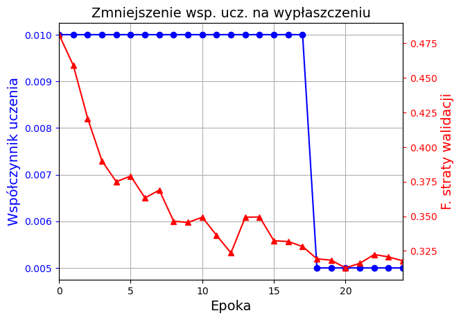

```python
# dodatkowy kod – komórka ta tworzy wykres harmonogramowania wydajnościowego

plt.plot(history.epoch, history.history["lr"], "bo-")
plt.xlabel("Epoka")
plt.ylabel("Współczynnik uczenia", color='b')
plt.tick_params('y', colors='b')
plt.gca().set_xlim(0, n_epochs - 1)
plt.grid(True)

ax2 = plt.gca().twinx()
ax2.plot(history.epoch, history.history["val_loss"], "r^-")
ax2.set_ylabel('F. straty walidacji', color='r')
ax2.tick_params('y', colors='r')

plt.title("Zmniejszenie wsp. ucz. na wypłaszczeniu", fontsize=14)
plt.show()
```

# Regularyzacja jako sposób na unikanie przetrenowania

## Regularyzacja $\ell_1$ i $\ell_2$

```python
layer = tf.keras.layers.Dense(100, activation="relu",
                              kernel_initializer="he_normal",
                              kernel_regularizer=tf.keras.regularizers.l2(0.01))
```

Ewentualnie wykorzystaj `l1(0.1)` dla regularyzacji ℓ<sub>1</sub> o współczynniku 0,1, albo `l1_l2(0.1, 0.01)` zarówno dla regularyzacji ℓ<sub>1</sub> i ℓ<sub>2</sub> ze współczynnikami, odpowiednio, 0,1 i 0,01.

```python
tf.random.set_seed(42)  # dodatkowy kod – dla odtwarzalności
```

```python
from functools import partial

RegularizedDense = partial(tf.keras.layers.Dense,
                           activation="relu",
                           kernel_initializer="he_normal",
                           kernel_regularizer=tf.keras.regularizers.l2(0.01))

model = tf.keras.Sequential([
    tf.keras.layers.Flatten(input_shape=[28, 28]),
    RegularizedDense(100),
    RegularizedDense(100),
    RegularizedDense(10, activation="softmax")
])
```

```python
# dodatkowy kod – kompiluje i trenuje model
optimizer = tf.keras.optimizers.SGD(learning_rate=0.02)
model.compile(loss="sparse_categorical_crossentropy", optimizer=optimizer,
              metrics=["accuracy"])
history = model.fit(X_train, y_train, epochs=2,
                    validation_data=(X_valid, y_valid))
```

## Porzucanie

```python
tf.random.set_seed(42)  # dodatkowy kod – dla odtwarzalności
```

```python
model = tf.keras.Sequential([
    tf.keras.layers.Flatten(input_shape=[28, 28]),
    tf.keras.layers.Dropout(rate=0.2),
    tf.keras.layers.Dense(100, activation="relu",
                          kernel_initializer="he_normal"),
    tf.keras.layers.Dropout(rate=0.2),
    tf.keras.layers.Dense(100, activation="relu",
                          kernel_initializer="he_normal"),
    tf.keras.layers.Dropout(rate=0.2),
    tf.keras.layers.Dense(10, activation="softmax")
])
```

```python
# dodatkowy kod – kompiluje i trenuje model
optimizer = tf.keras.optimizers.SGD(learning_rate=0.01, momentum=0.9)
model.compile(loss="sparse_categorical_crossentropy", optimizer=optimizer,
              metrics=["accuracy"])
history = model.fit(X_train, y_train, epochs=10,
                    validation_data=(X_valid, y_valid))
```

```python
model.evaluate(X_train, y_train)
```

```
[0.3161194324493408, 0.8827636241912842]
```

```python
model.evaluate(X_test, y_test)
```

```
[0.3706876039505005, 0.8652999997138977]
```

**Uwaga**: upewnij się, że korzystasz z `AlphaDropout` zamiast `Dropout`, jeśli chcesz zbudować samonormalizującą sieć neuronową za pomocą funkcji aktywacji SELU.